# Introduction

```
The goal of this project is to analyze data from the bike rental service "Bay Wheels" and provide business insights for the management team. To achieve this, we will begin by using pandas to analyze the dataset in bikes_data.xlsx. Specifically, we will examine the relationship between bike usage and factors such as time of day and temperature. Based on these findings, we will answer key analysis questions and outline our top business insights. Finally, we will conclude the analysis with a summary of our main takeaways.
```

```python
#Imput data
import pandas as pd
import numpy as np
import seaborn as sns
import matplotlib.pyplot as plt

file = "bikes_data.xlsx"

df   = pd.read_excel(io        = file,
                    sheet_name = 0,
                    header     = 0)

print(df.head(n=10))
```

```
   ID Month Day of Week  Hour  Temperature  Humidity  Wind Speed  Visibility  \
0   1   Jan      Sunday     0         -3.2        40         0.5        1358
1   2   Jan      Sunday    13          2.4        22         2.3        1921
2   3   Jan      Sunday    16          3.0        28         2.5        1864
3   4   Jan      Sunday    17          1.8        33         3.3        1913
4   5   Jan      Sunday    20         -0.3        40         1.2        1936
5   6   Jan      Monday    10         -1.4        50         1.9        1355
6   7   Jan      Monday    18         -0.8        24         2.3        2000
7   8   Jan     Tuesday    21         -4.3        47         2.8        1997
8   9   Jan   Wednesday     3         -7.4        54         1.7        1968
9  10   Jan   Wednesday     7         -8.1        51         0.5        1987

   Dew Point Temperature  UV Index  Rainfall  Snowfall  Season Holiday  \
0                  -14.9      0.00       0.0       0.0  Winter     Yes
1                  -17.2      1.10       0.0       0.0  Winter     Yes
```

[output cut: 20 more lines]

```python
# Data type
print(df.info())
```

```
<class 'pandas.core.frame.DataFrame'>
RangeIndex: 1387 entries, 0 to 1386
Data columns (total 15 columns):
 #   Column                 Non-Null Count  Dtype
---  ------                 --------------  -----
 0   ID                     1387 non-null   int64
 1   Month                  1387 non-null   object
 2   Day of Week            1387 non-null   object
 3   Hour                   1387 non-null   int64
 4   Temperature            1387 non-null   float64
 5   Humidity               1387 non-null   int64
 6   Wind Speed             1387 non-null   float64
 7   Visibility             1387 non-null   int64
 8   Dew Point Temperature  1387 non-null   float64
 9   UV Index               1387 non-null   float64
 10  Rainfall               1387 non-null   float64
 11  Snowfall               1387 non-null   float64
 12  Season                 1387 non-null   object
 13  Holiday                1387 non-null   object
 14  RENTALS                1387 non-null   int64
dtypes: float64(6), int64(5), object(4)
memory usage: 162.7+ KB
None
```

```python
# Missing value check
print(df.isnull().sum())
```

```
ID                       0
Month                    0
Day of Week              0
Hour                     0
Temperature              0
Humidity                 0
Wind Speed               0
Visibility               0
Dew Point Temperature    0
UV Index                 0
Rainfall                 0
Snowfall                 0
Season                   0
Holiday                  0
RENTALS                  0
dtype: int64
```

```python
# Value check
print(df.describe())
```

```
                ID         Hour  Temperature     Humidity   Wind Speed  \
count  1387.000000  1387.000000  1387.000000  1387.000000  1387.000000
mean    694.000000    11.553713    13.093511    58.759193     1.707714
std     400.536723     6.924075    11.902220    20.559202     1.019488
min       1.000000     0.000000   -15.800000    11.000000     0.000000
25%     347.500000     6.000000     3.200000    43.000000     0.900000
50%     694.000000    12.000000    14.100000    58.000000     1.500000
75%    1040.500000    18.000000    22.800000    75.000000     2.300000
max    1387.000000    23.000000    38.000000    98.000000     7.400000

        Visibility  Dew Point Temperature     UV Index     Rainfall  \
count  1387.000000            1387.000000  1387.000000  1387.000000
mean   1434.423216               4.365537     0.573338     0.139005
std     618.087288              13.100902     0.869165     1.262159
min      81.000000             -30.500000     0.000000     0.000000
25%     946.000000              -4.400000     0.000000     0.000000
50%    1718.000000               5.200000     0.010000     0.000000
75%    2000.000000              15.600000     0.975000     0.000000
max    2000.000000              26.600000     3.450000    35.000000

          Snowfall      RENTALS
count  1387.000000  1387.000000
mean      0.079813   810.015862
std       0.444182   694.720990
min       0.000000     5.000000
25%       0.000000   250.500000
50%       0.000000   626.000000
75%       0.000000  1196.500000
max       7.000000  3734.000000
```

## Visualizations

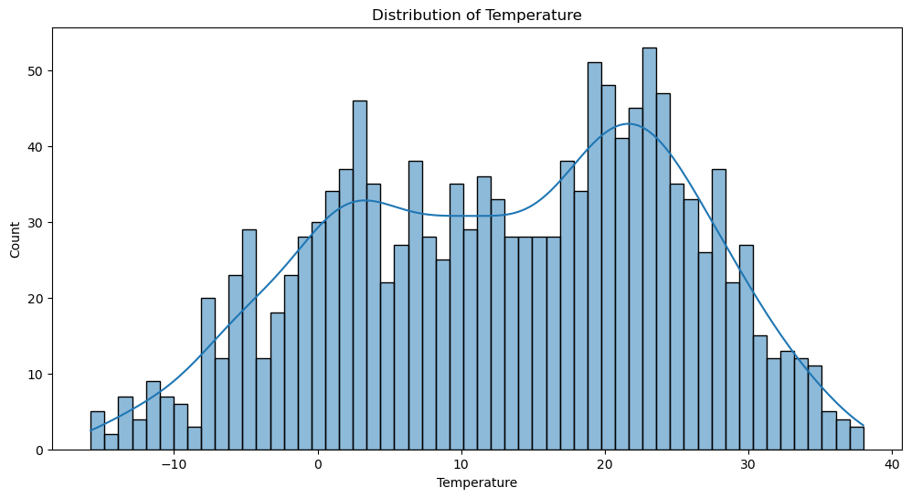

```python
#Distribution of Temperature
plt.figure(figsize=(12,6))
sns.histplot(data=df, x='Temperature', bins=56, kde=True)
plt.title('Distribution of Temperature')
plt.xlabel('Temperature')
plt.ylabel('Count')
plt.show()
```

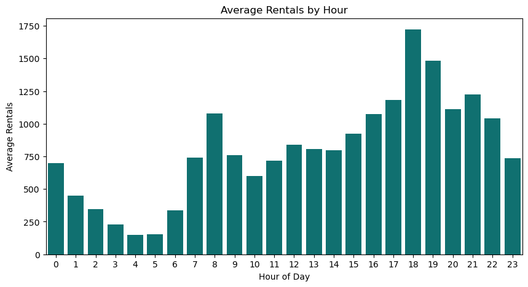

```python
# Rentals by hour
plt.figure(figsize=(10, 5))
sns.barplot(data=df, x='Hour', y='RENTALS', errorbar=None, color= 'teal')
plt.title('Average Rentals by Hour')
plt.xlabel('Hour of Day')
plt.ylabel('Average Rentals')
plt.show()
```

The second graph analyzes bike usage across the 24 hours of a day to understand when people are most likely to use the service. The highest number of rentals occurs around 6 PM, with another noticeable spike around 8 AM. This pattern likely reflects typical commuting hours for work or school. After the 6 PM peak, ridership gradually declines, with the lowest usage seen around 4 AM and 5 AM. Overall, this graph suggests that the majority of users are local residents who rely on the bikes as part of their daily routine.

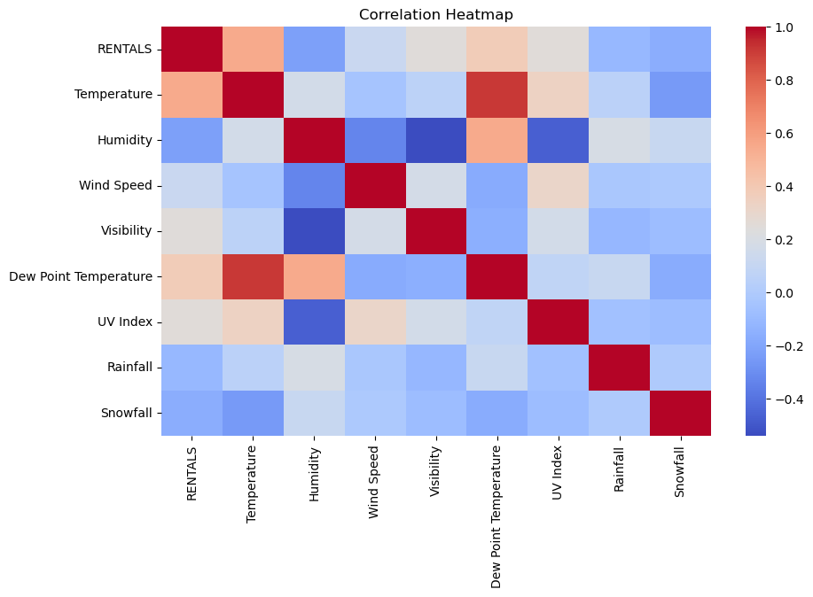

```python
# Correlation heatmap
plt.figure(figsize=(10, 6))
sns.heatmap(df[['RENTALS', 'Temperature', 'Humidity', 'Wind Speed', 'Visibility',
                'Dew Point Temperature', 'UV Index', 'Rainfall', 'Snowfall']].corr(), annot= False, cmap='coolwarm')
plt.title('Correlation Heatmap')
plt.show()
```

In the correlation heatmap, it shows weather conditions and bike rentals. Warm colors like red represent strong positive correlation, which means those conditions have a higher percentage to influence the rentals. Cooler colors like blue have lower percentage to impact the rentals. Based on the dataset, temperature has the strongest positive correlation with rentals, which means people prefer to rent bikes on warm and comfortable days. On the other hand, humidity and rainfall have negative correlation, showing that bad weather conditions can reduce demand. Other factors like visibility and dew point temperature also show a weak but positive relationship, which means that clear and comfortable conditions, for example, sunny days or temperatures between 22 to 26 degree Celsius may make more people want to use the bike.

## Questions

**1. In your analytical opinion, why are the majority of users renting bicycles?**

[output not shown]

**2. Are there ideal weather conditions that create high bike rental demand? If so, what are they?**

```
Yes, bike rentals clearly go up when the weather is nice. People are more likely to ride when the temperature is comfortable typically between 18 to 24 degrees Celsius. Sunny or partly cloudy days tend to bring out more riders, while rainy days or extreme heat or cold usually keep people away. Wind and humidity also play a role calm, dry days are definitely more appealing. All of this helps explain why spring and fall are the busiest seasons for bike rentals, while winter tends to be much slower because of the less favorable weather.
```

**3. How should the company strategize based on your results? In other words, what actionable steps can the company take in order to take advantage of your insights.**

```
The company could run seasonal promotions targeting annual subscribers in the spring and fall to boost ridership during these high demand periods. On days with poor weather or during slower seasons, offering discounts or loyalty points could help encourage continued use. A point system that lets Bay Wheels users earn rewards toward Lyft rides, for example, could be a smart way to attract new customers and increase usage frequency. It would also be beneficial to implement a system that uses real time weather data to predict demand and optimize bike distribution accordingly. Lastly, adding features to the app such as route suggestions based on weather and traffic, or tracking calories burned and CO₂ saved would enhance the user experience and help turn occasional riders into loyal ones.
```

## Business Insights

1.Bike rentals tend to peak during the morning and evening rush hours, suggesting that most users are local commuters rather than tourists. This shows that Bay Wheels is being used more as a practical daily transportation option than for leisure. To take advantage of this trend, the company could increase bike availability during commute hours and introduce commuter focused perks like "commuter passes" or special bundles. These steps would likely boost customer satisfaction and encourage long term use.

2.Bike rentals increase significantly on clear and mild days, typically when temperatures range between 15 to 27 degrees Celsius. On the other hand, usage tends to drop on rainy days or when the weather is extremely hot or cold. Given this seasonal fluctuation, it's important for the company to adjust its pricing and marketing strategies based on demand. For example, boosting bike availability and running promotions in the spring and fall, while offering discounts or reward points during winter or rainy days, could help maintain steady revenue throughout the year. Additionally, installing windshields on bike handlebars similar to those used on motorcycles might encourage more people to ride during colder months.

3.By using real time weather forecasts and demand predictions, Bay Wheels can optimize bike distribution and inventory management, leading to greater operational efficiency. In addition, adding features to the app such as suggested routes based on weather and traffic conditions, visual displays of calories burned and CO₂ emissions reduced, and integration with Lyft’s point system can significantly enhance the user experience. These features are likely to appeal to health and eco conscious users, encouraging repeat rides and helping attract new customers through word of mouth.

# Conclusion

This analysis makes it clear that Bay Wheels is used more by local residents for commuting and everyday travel than by tourists. Usage peaks during the morning and evening rush hours, showing that bike rentals have become a part of people’s daily routines. We also found that rental numbers increase significantly on days with comfortable temperatures around 18 to 24 degrees Celsius which are typical of San Francisco’s spring and fall. These seasons clearly drive the highest demand. On the other hand, bike usage tends to drop sharply on rainy days or when the weather is too hot or too cold. Given these trends, Bay Wheels has a strong opportunity to expand its user base by reinforcing service availability during commuting hours and high-demand seasons, while offering discounts or reward points during bad weather and off-peak times. Implementing real-time weather-based inventory adjustments, and enhancing the app with features like suggested routes, calorie and CO₂ tracking, and integration with Lyft’s reward system, could also make the service more appealing. By continuing to build a flexible, user-centered service, Bay Wheels has the potential to grow as an essential part of urban life and earn even greater support from the community.